# Intro to R: A Workshop for HPCC Users (R language fundamentals)

[figure not shown]

George G. Vega Yon  
University of Southern California  
Department of Preventive Medicine

July 7th, 2018

# Getting Started

## Creating objects

- In R you can create new objects by either using the assign operator (`<-`) or the equal sign `=`, for example, the following 2 are equivalent:

  ```r
  a <- 1
  a =  1
  ```

  And it works for any type of data

  ```r
  # Hey! here is a comment!.
  # Comments in R can be either at the begining of a line ...
  b <- "aloha" # ... or at the end of it!
  ```

  Historically the assign operator is the most common used.

## Data types

- The most basic data (object) type in R are vectors.

  ```r
  myvec1 <- vector("logical", 3)  # This is a logical vector of length 3
  myvec2 <- c(FALSE, TRUE, FALSE) # This is ALSO a logical vector of length 3
  myvec2
  ```

  ```
  ## [1] FALSE  TRUE FALSE
  ```

  ```r
  length(myvec2)
  ```

  ```
  ## [1] 3
  ```

- Vectors can be of different modes: `logical`, `integer`, `numeric` (double), `complex`, `character`, and `raw`. (so one mode per vector!).
- Vectors can also be lists, which is a VERY special type of object in R (most of its objects are lists!)

- Moreover, lists elements can have names

  ```r
  mylist2 <- list(first = NULL, second = 1, third = c("a", "b", "c"))
  mylist2
  ```

  ```
  ## $first
  ## NULL
  ##
  ## $second
  ## [1] 1
  ##
  ## $third
  ## [1] "a" "b" "c"
  ```

  And we can access them as follows

  ```r
  # Getting the 3rd element of the list
  mylist2$third      # By name using the dollar sign
  mylist2[[3]]       # By position
  mylist2[["third"]] # By name using a string
  ```

  ```
  ## [1] "a" "b" "c"
  ```

# Attributes and Structure

- Objects in R have attributes (metadata)

  ```r
  # Here are the attributes of the iris dataset
  attributes(iris)
  ```

  ```
  ## $names
  ## [1] "Sepal.Length" "Sepal.Width"  "Petal.Length" "Petal.Width"
  ## [5] "Species"
  ##
  ## $class
  ## [1] "data.frame"
  ##
  ## $row.names
  ##   [1]   1   2   3   4   5   6   7   8   9  10  11  12  13  14  15  16  17
  ##  [18]  18  19  20  21  22  23  24  25  26  27  28  29  30  31  32  33  34
  ##  [35]  35  36  37  38  39  40  41  42  43  44  45  46  47  48  49  50  51
  ##  [52]  52  53  54  55  56  57  58  59  60  61  62  63  64  65  66  67  68
  ##  [69]  69  70  71  72  73  74  75  76  77  78  79  80  81  82  83  84  85
  ##  [86]  86  87  88  89  90  91  92  93  94  95  96  97  98  99 100 101 102
  ## [103] 103 104 105 106 107 108 109 110 111 112 113 114 115 116 117 118 119
  ## [120] 120 121 122 123 124 125 126 127 128 129 130 131 132 133 134 135 136
  ## [137] 137 138 139 140 141 142 143 144 145 146 147 148 149 150
  ```

- You can take a general look at the structure of an R object with the `str()` function

  ```r
  # Let's take a look at the iris dataset, again
  str(iris)
  ```

  ```
  ## 'data.frame':    150 obs. of  5 variables:
  ##  $ Sepal.Length: num  5.1 4.9 4.7 4.6 5 5.4 4.6 5 4.4 4.9 ...
  ##  $ Sepal.Width : num  3.5 3 3.2 3.1 3.6 3.9 3.4 3.4 2.9 3.1 ...
  ##  $ Petal.Length: num  1.4 1.4 1.3 1.5 1.4 1.7 1.4 1.5 1.4 1.5 ...
  ##  $ Petal.Width : num  0.2 0.2 0.2 0.2 0.2 0.4 0.3 0.2 0.2 0.1 ...
  ##  $ Species     : Factor w/ 3 levels "setosa","versicolor",..: 1 1 1 1 1 1 1 1 1 1 ...
  ```

# Missing values

R has different types of Missing values:

- `NA`: no information, has length 1,
- `NULL`: which has length 0,
- `Inf`: Infinite, and
- `NaN`: Not a Number

```r
str(c(NA, 1L))        # Integers can have NAs
##  int [1:2] NA 1
str(c(NaN, 1L, Inf))  # But not NaN or Inf (automatic coercion)
##  num [1:3] NaN 1 Inf
str(c(-Inf, 1, NULL, +Inf)) # And Nulls are... of length 0!
##  num [1:3] -Inf 1 Inf
```

- These have companion functions `is.na()`, `is.null`, `is.infinite` (or `is.finite()`, which covers NA, Inf, and NaN), and `is.nan`.

  ```r
  myvector <- c(NA, NaN, Inf)
  is.na(myvector)
  ```

  ```
  ## [1]  TRUE  TRUE FALSE
  ```

  ```r
  is.infinite(myvector)
  ```

  ```
  ## [1] FALSE FALSE  TRUE
  ```

  ```r
  is.finite(myvector)
  ```

  ```
  ## [1] FALSE FALSE FALSE
  ```

  ```r
  is.nan(myvector)
  ```

  ```
  ## [1] FALSE  TRUE FALSE
  ```

# Other fundamental types

Other fundamental type of objects in R are

- **Matrix**: A special class of array, are vectors with a `dim` attribute of length 2 (number of rows and number of columns).

  ```r
  mymat <- matrix(1:9, ncol=3) # A matrix with numbers 1 through 9 with 3 columns
  mymat
  ```

  ```
  ##      [,1] [,2] [,3]
  ## [1,]    1    4    7
  ## [2,]    2    5    8
  ## [3,]    3    6    9
  ```

  ```r
  str(mymat)
  ```

  ```
  ##  int [1:3, 1:3] 1 2 3 4 5 6 7 8 9
  ```

  R stores elements in column major-order. We can access matrices elements in the following way.

  ```r
  mymat[1, 2] # The element in the (1, 2) location of the matrix
  ## [1] 4
  mymat[4]    # The fourth element in the vector... which is (1, 2)
  ## [1] 4
  ```

- **Factors**: A set of *integer codes* with labels (levels).

  ```r
  myfactor <- factor(c("a", "a", "b", "xyz"))
  myfactor
  ```

  ```
  ## [1] a   a   b   xyz
  ## Levels: a b xyz
  ```

  We treat factors as vectors.
- **Data frames**: “A data frame is a list of variables of the same number of rows with unique row names, given class”data.frame“.”

  ```r
  # Data frames can have multiple type objects, here, factor and numeric
  mydf <- data.frame(a_letter = c("a", "b", "c"), a_number = c(1, 2, 100))
  mydf
  ```

  ```
  ##   a_letter a_number
  ## 1        a        1
  ## 2        b        2
  ## 3        c      100
  ```

  ```r
  str(mydf)
  ```

  ```
  ## 'data.frame':    3 obs. of  2 variables:
  ##  $ a_letter: Factor w/ 3 levels "a","b","c": 1 2 3
  ##  $ a_number: num  1 2 100
  ```

  We can access data frame objects as follow

  ```r
  mydf$a_letter      # Dollar sign
  mydf[[1]]          # Position of the column
  mydf[["a_letter"]] # Name of the column
  ```

  ```
  ## [1] a b c
  ## Levels: a b c
  ```

# R has several type of objects, the most basic structures in R are:

1. `vectors`,
2. `matrix`,
3. `list`,
4. `data.frame`

```r
a_vector     <- 1:9
another_vect <- c(1, 2, 3, 4, 5, 6, 7, 8, 9)
a_string_vec <- c("I", "like", "netdiffuseR")
a_matrix     <- matrix(a_vector, ncol = 3)
a_string_mat <- matrix(letters[1:9], ncol=3) # Matrices can be of strings too
another_mat  <- cbind(1:4, 11:14) # The `cbind` operator does "column bind"
another_mat2 <- rbind(1:4, 11:14) # The `rbind` operator does "row bind"
a_string_mat <- matrix(letters[1:9], ncol = 3)
a_list       <- list(a_vector, a_matrix)
another_list <- list(my_vec = a_vector, my_mat = a_matrix) # same but with names!
# Data frames can have multiple types of elements, it is a collection of lists
a_data_frame <- data.frame(x = 1:10, y = letters[1:10])
```

3. Depending on the type of object, we can access to its components using indexing:

   ```r
   a_vector[1:3] # First 3 elements
   ```

   ```
   ## [1] 1 2 3
   ```

   ```r
   a_string_vec[3] # Third element
   ```

   ```
   ## [1] "netdiffuseR"
   ```

   ```r
   a_matrix[1:2, 1:2] # A sub matrix
   ```

   ```
   ##      [,1] [,2]
   ## [1,]    1    4
   ## [2,]    2    5
   ```

   ```r
   a_matrix[,3] # Third column
   ```

   ```
   ## [1] 7 8 9
   ```

   ```r
   a_matrix[3,] # Third row
   ```

   ```
   ## [1] 3 6 9
   ```

   ```r
   a_string_mat[1:6] # First 6 elements of the matrix. R stores matrices by column.
   ```

   ```
   ## [1] "a" "b" "c" "d" "e" "f"
   ```

   ```r
   # These three are equivalent
   another_list[[1]]
   ```

   ```
   ## [1] 1 2 3 4 5 6 7 8 9
   ```

   ```r
   another_list$my_vec
   ```

   ```
   ## [1] 1 2 3 4 5 6 7 8 9
   ```

   ```r
   another_list[["my_vec"]]
   ```

   ```
   ## [1] 1 2 3 4 5 6 7 8 9
   ```

   ```r
   # Data frames are just like lists
   a_data_frame[[1]]
   ```

   ```
   ##  [1]  1  2  3  4  5  6  7  8  9 10
   ```

   ```r
   a_data_frame[,1]
   ```

   ```
   ##  [1]  1  2  3  4  5  6  7  8  9 10
   ```

   ```r
   a_data_frame[["x"]]
   ```

   ```
   ##  [1]  1  2  3  4  5  6  7  8  9 10
   ```

   ```r
   a_data_frame$x
   ```

   ```
   ##  [1]  1  2  3  4  5  6  7  8  9 10
   ```

4. Control-flow statements

   ```r
   # The oldfashion forloop
   for (i in 1:10) {
     print(paste("I'm step", i, "/", 10))
   }
   ```

   ```
   ## [1] "I'm step 1 / 10"
   ## [1] "I'm step 2 / 10"
   ## [1] "I'm step 3 / 10"
   ## [1] "I'm step 4 / 10"
   ## [1] "I'm step 5 / 10"
   ## [1] "I'm step 6 / 10"
   ## [1] "I'm step 7 / 10"
   ## [1] "I'm step 8 / 10"
   ## [1] "I'm step 9 / 10"
   ## [1] "I'm step 10 / 10"
   ```

   ```r
   # A nice ifelse

   for (i in 1:10) {

     if (i %% 2) # Modulus operand
       print(paste("I'm step", i, "/", 10, "(and I'm odd)"))
     else
       print(paste("I'm step", i, "/", 10, "(and I'm even)"))

   }
   ```

   ```
   ## [1] "I'm step 1 / 10 (and I'm odd)"
   ## [1] "I'm step 2 / 10 (and I'm even)"
   ## [1] "I'm step 3 / 10 (and I'm odd)"
   ## [1] "I'm step 4 / 10 (and I'm even)"
   ## [1] "I'm step 5 / 10 (and I'm odd)"
   ## [1] "I'm step 6 / 10 (and I'm even)"
   ## [1] "I'm step 7 / 10 (and I'm odd)"
   ## [1] "I'm step 8 / 10 (and I'm even)"
   ## [1] "I'm step 9 / 10 (and I'm odd)"
   ## [1] "I'm step 10 / 10 (and I'm even)"
   ```

   ```r
   # A while
   i <- 10
   while (i > 0) {
     print(paste("I'm step", i, "/", 10))
     i <- i - 1
   }
   ```

   ```
   ## [1] "I'm step 10 / 10"
   ## [1] "I'm step 9 / 10"
   ## [1] "I'm step 8 / 10"
   ## [1] "I'm step 7 / 10"
   ## [1] "I'm step 6 / 10"
   ## [1] "I'm step 5 / 10"
   ## [1] "I'm step 4 / 10"
   ## [1] "I'm step 3 / 10"
   ## [1] "I'm step 2 / 10"
   ## [1] "I'm step 1 / 10"
   ```

5. R has a very nice set of pseudo random number generation functions. In general, distribution functions have the following name structure:
   1. Random Number Generation: `r[name-of-the-distribution]`, e.g. `rnorm` for normal, `runif` for uniform.
   2. Density function: `d[name-of-the-distribution]`, e.g. `dnorm` for normal, `dunif` for uniform.
   3. Cumulative Distribution Function (CDF): `p[name-of-the-distribution]`, e.g. `pnorm` for normal, `punif` for uniform.
   4. Inverse (quantile) function: `q[name-of-the-distribution]`, e.g. `qnorm` for the normal, `qunif` for the uniform.

   Here are some examples:

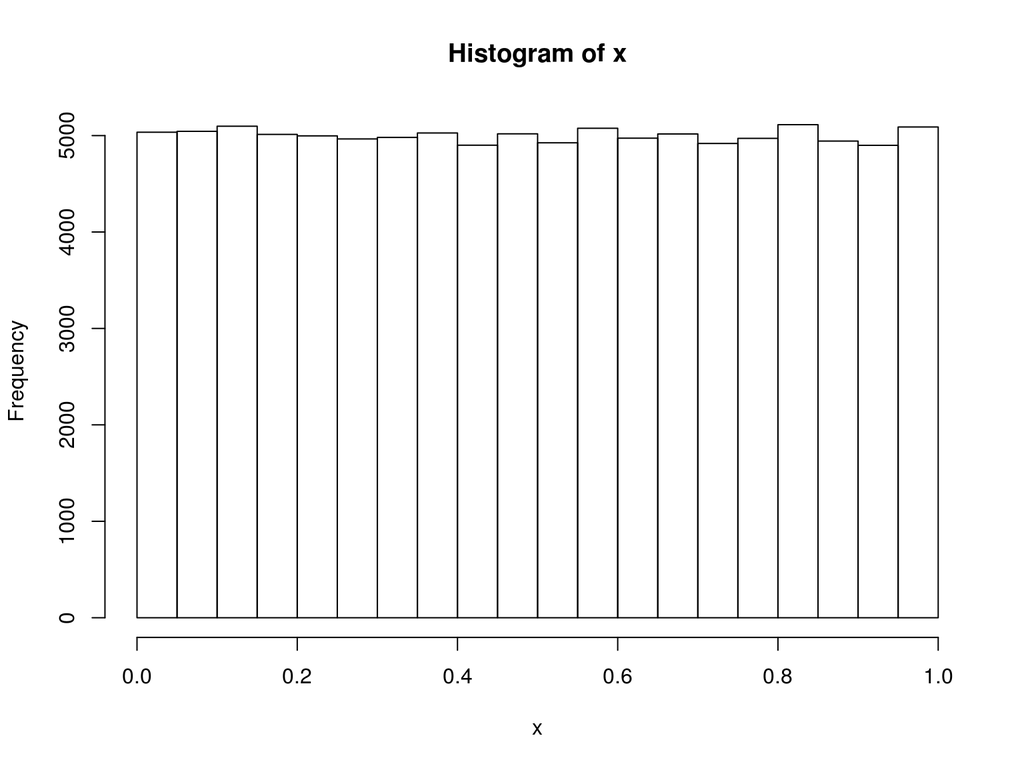

   ```r
   # To ensure reproducibility
   set.seed(1231)

   # 100,000 Unif(0,1) numbers
   x <- runif(1e5)
   hist(x)
   ```

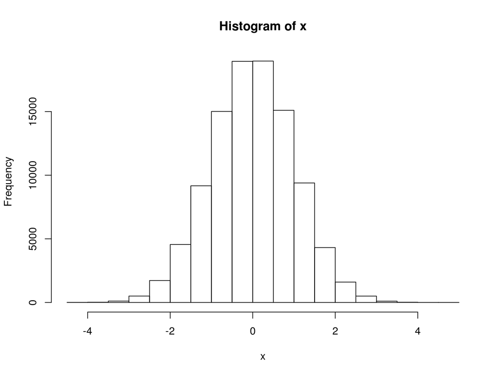

   ```r
   # 100,000 N(0,1) numbers
   x <- rnorm(1e5)
   hist(x)
   ```

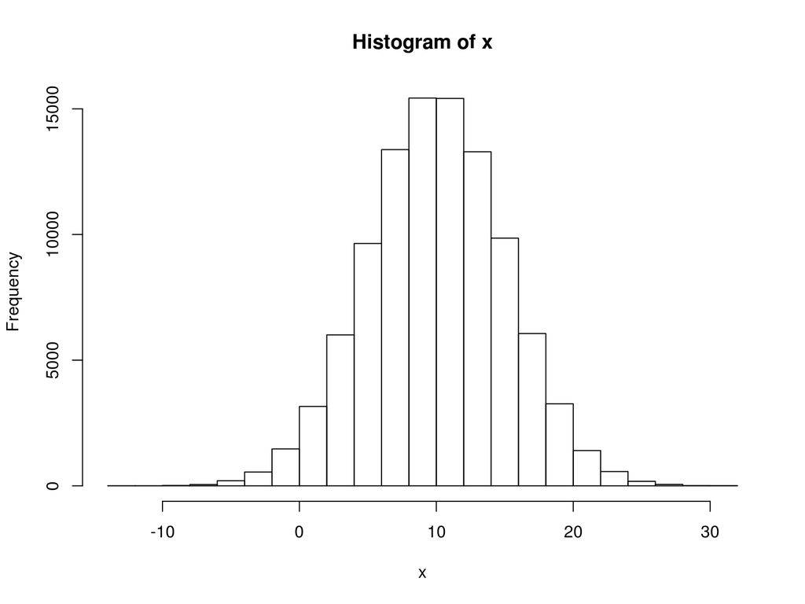

   ```r
   # 100,000 N(10,25) numbers
   x <- rnorm(1e5, mean = 10, sd = 5)
   hist(x)
   ```

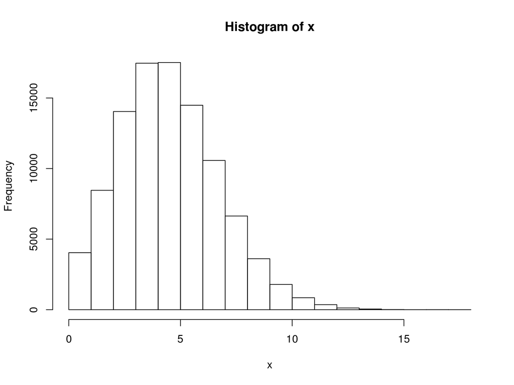

   ```r
   # 100,000 Poisson(5) numbers
   x <- rpois(1e5, lambda = 5)
   hist(x)
   ```

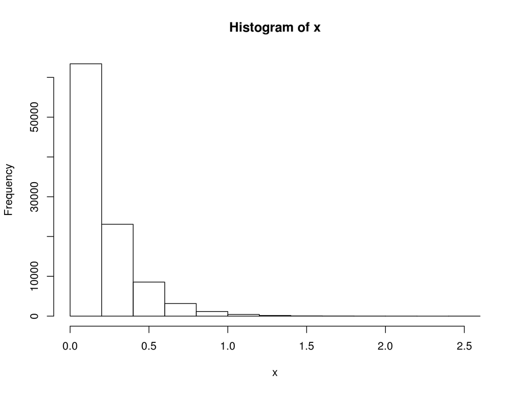

   ```r
   # 100,000 rexp(5) numbers
   x <- rexp(1e5, 5)
   hist(x)
   ```

   More distributions available at `??Distributions`.

For a nice intro to R, take a look at [“The Art of R Programming” by Norman Matloff](https://nostarch.com/artofr.htm). For more advanced users, take a look at [“Advanced R” by Hadley Wickham](http://adv-r.had.co.nz/).